# R para el modulo 1

MIDE

03/9/2022

# Conjuntos

En R se pueden hacer algunas operaciones con conjuntos, aunque no es estrictamente formal en todas las operaciones como en matemáticas. R tiene algunos comandos y paquetes que ayudan al manejo de conjuntos

Consideremos un **vector** como si fuera un conjunto.

```r
x <- c(1,4,3,5,6,6,72,3)
y <- 1:8
```

En R, las operaciones básicas de conjuntos son:

- pertenencia

```r
is.element(6,x)
```

```
[1] TRUE
```

- unión

```r
union(x,y)
```

```
[1]  1  4  3  5  6 72  2  7  8
```

- intersección

```r
intersect(x,y)
```

```
[1] 1 4 3 5 6
```

- diferencia de conjuntos: $A-B$ significa los elementos que estan en $A$ pero que no están en $B$.

```r
setdiff(x,y) # la diferencia de x & y
```

```
[1] 72
```

```r
setdiff(y,x) # la diferencia de y & x
```

```
[1] 2 7 8
```

- comparación de conjuntos

```r
setequal(x,y)
```

```
[1] FALSE
```

```r
z <- 8:1 # valores de y pero en otro orden
setequal(y,z)
```

```
[1] TRUE
```

También es posible hacer algunos ejemplos de diagramas de Venn, utilizando algunos. El paquete `RVenn` permite hacer operaciones con conjuntos y con los diagramas de Venn

```r
#install.packages("RVenn")
library(RVenn)
# Para definir conjuntos, hay que crear una lista con los diferentes conjuntos que se van
# a trabajar
A <- c("e","o","j","b","f") # El conjunto A tiene 5 elementos
B <- c(letters[1:5],"o")
set.seed(10) # fija la semilla del generador de números aleatorios
C <- sample(letters,10) # toma una muestra aleatoria del conjunto de letras de tamaño 10.
D <- c("e","o","k","K","L")
E <- NULL #Conjunto vacío.
Conjuntos <- list(A = A, B = B, C = C, D = D, Vacio = E)
```

Ahora la decimos a R que los conjuntos con los que se operará son los que estan en la lista

```r
Omega <- Venn(Conjuntos) # Convierte la lista que tenemos a un universo de elementos.
```

Las funciones de conjuntos en el paquete se llaman diferente:

- overlap: intersect
- unite: union
- discern: setdiff

```r
overlap(Omega) # Consider la intersección de todos los conjuntos.
```

```
[1] "o"
```

```r
overlap(Omega, slice = c("A","Vacio"))
```

```r
overlap(Omega, slice = c("A","B","D"))
```

```
[1] "e" "o"
```

```r
overlap_pairs(Omega, slice = c(1,2,4))
```

```
$A...B
[1] "e" "o" "b"

$A...D
[1] "e" "o"

$B...D
[1] "e" "o"
```

```r
#También se puede poner (aunque no da los nombres correctos):
overlap_pairs(Omega, slice = c("A","B","D"))
```

```
$NA...NA
[1] "e" "o" "b"

$NA...NA
[1] "e" "o"

$NA...NA
[1] "e" "o"
```

```r
unite(Omega, slice = c("A","D"))
```

```
[1] "e" "o" "j" "b" "f" "k" "K" "L"
```

```r
discern(Omega, slice1 = c("A","B"),slice2 = "D")
```

```
[1] "j" "b" "f" "a" "c" "d"
```

Para hacer diagramas de Venn, podemos usar la función del paquete que se llama `ggvenn`, pero está limitada a dos o tres conjuntos.

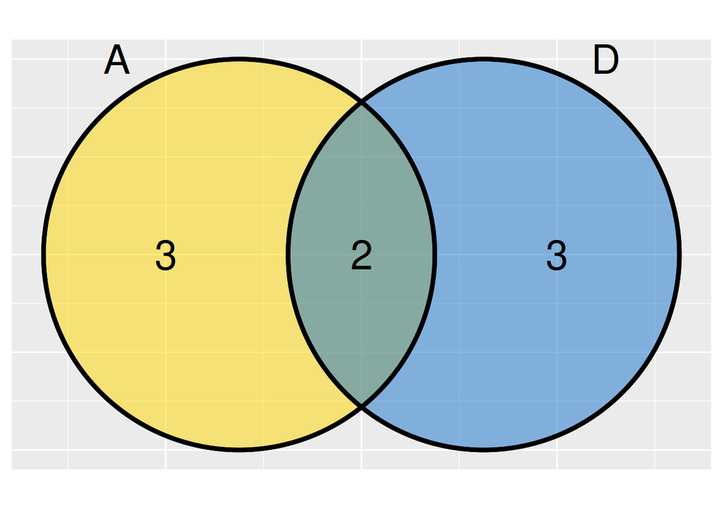

```r
library(ggplot2) # se requiere para la gráfica.
ggvenn(Omega, slice = c("A","D"))
```

Hay otro paquete que se llama exactamente igual que la función `ggvenn` pero permite hacer mas conjuntos.

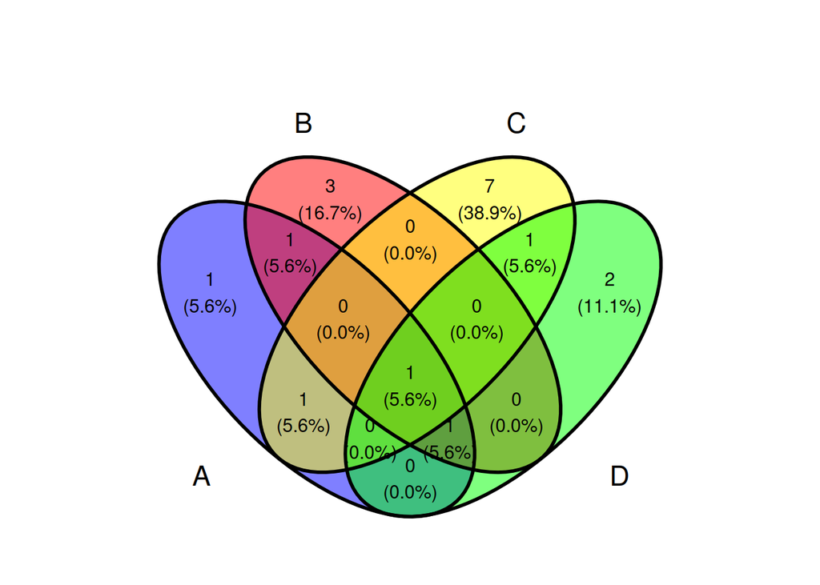

```r
library(ggvenn)
ggvenn::ggvenn(Conjuntos,
               fill_color = c("blue","red","yellow","green"))
```

Vamos a considerar un ejemplo “grande”:

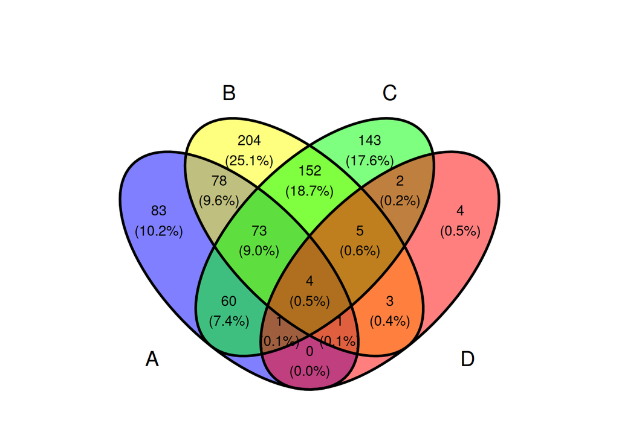

```r
set.seed(5) # Fijamos la semilla en uno
etiquetas <- paste0("a",1:1000)
X <- list(
       A = sample(etiquetas, 300),
       B = sample(etiquetas, 520),
       C = sample(etiquetas, 440),
       D = sample(etiquetas, 20))
ggvenn::ggvenn(X)
```

```r
# Para saber qué elementos estan en cada intersección
XOm <- Venn(X)
discern(XOm,slice1 = "C", slice2 = c("A","B","D"))
```

```
  [1] "a937" "a917" "a978" "a219" "a252" "a436" "a438" "a13"  "a695" "a722"
 [11] "a320" "a410" "a633" "a579" "a587" "a480" "a437" "a729" "a974" "a837"
 [21] "a161" "a770" "a138" "a266" "a309" "a851" "a171" "a955" "a61"  "a63"
 [31] "a653" "a802" "a296" "a690" "a105" "a817" "a598" "a749" "a615" "a507"
 [41] "a62"  "a175" "a356" "a632" "a761" "a337" "a554" "a23"  "a12"  "a202"
 [51] "a812" "a402" "a794" "a465" "a612" "a498" "a298" "a332" "a874" "a555"
 [61] "a286" "a81"  "a860" "a114" "a689" "a86"  "a936" "a147" "a626" "a820"
 [71] "a515" "a964" "a165" "a467" "a405" "a782" "a696" "a647" "a316" "a961"
 [81] "a721" "a619" "a142" "a76"  "a549" "a827" "a693" "a831" "a417" "a101"
 [91] "a9"   "a95"  "a996" "a449" "a726" "a738" "a911" "a275" "a614" "a196"
[101] "a354" "a486" "a106" "a717" "a815" "a173" "a895" "a531" "a493" "a168"
[111] "a273" "a104" "a713" "a388" "a64"  "a931" "a193" "a335" "a376" "a736"
[121] "a180" "a205" "a608" "a602" "a558" "a552" "a720" "a818" "a167" "a928"
[131] "a991" "a230" "a502" "a217" "a160" "a866" "a551" "a11"  "a301" "a791"
[141] "a744" "a838" "a488"
```

# Sobre Números

```r
x <- c(1,2,3,NA,4,10)
x + 3
```

```
[1]  4  5  6 NA  7 13
```

```r
is.na(x)
```

```
[1] FALSE FALSE FALSE  TRUE FALSE FALSE
```

```r
which(is.na(x)) # Qué elemento de un vector cumple con cierta condición.
```

```
[1] 4
```

El simbolo `NaN` significa *Not a Number* ,`Inf` denota infinito y `-Inf` es menos infinito

```r
# Algo de aritmética con infinitos y ceros
Inf + 81392973917297929
```

```
[1] Inf
```

```r
Inf*(-162979)
```

```
[1] -Inf
```

```r
Inf*Inf
```

```
[1] Inf
```

```r
Inf*(-Inf)
```

```
[1] -Inf
```

```r
Inf/Inf
```

```
[1] NaN
```

```r
524/0
```

```
[1] Inf
```

```r
0/Inf
```

```
[1] 0
```

```r
0*Inf
```

```
[1] NaN
```

```r
1/Inf
```

```
[1] 0
```

```r
NaN*3
```

```
[1] NaN
```

`NULL` es el objeto vacío o nulo. Un objeto nulo siempre tiene longitud 0. Se interpreta como el conjunto vacío.

```r
x <- NULL
length(x)
```

```
[1] 0
```

```r
x <- append(x,1) # Sirve para inicializar listas o vectores.
```

# Funciones y gráficas de funciones

En R la funciones son prácticamente iguales a las funciones como se definen en matemáticas. Por otro lado, generar gráficas con R puede ser muy fácil o extremadamente complicado, pero siempre es divertido.

La estructura de una función en R

```r
  mifuncion <- function(argumentos){
    # Poner aquí lo que hace la función
    return(loqueregresalafunción)  #EL return no siempre es necesario
  }
```

Las funciones puede devolver como salida números, vectores, matrices, listas, mensajes, gráficas, etc.

```r
f <- function(x){
     sin(x^2 + 2)/(x+3)
}

f(1)
```

```
[1] 0.03528
```

```r
f(c(1,5,10)) # algunas operaciones son vectorizadas
```

```
[1] 0.03528000 0.11954699 0.07652514
```

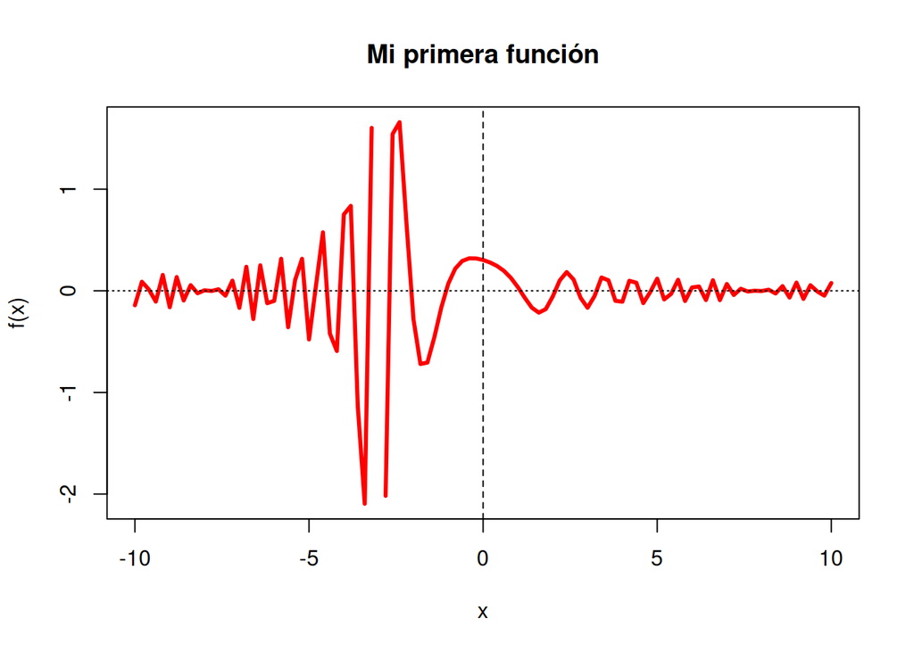

```r
curve(f, from = -10, to = 10,
         main = "Mi primera función",
         col = "red",
         lwd = 3)
abline(v=0, lty = 2)
abline(h=0, lty = 3)
```

Esta función es un polinomio de grado 3

```r
pol3 <- function(x){
           3*x^3 - 2*x^2 + 5*x - 2
}
pol3(2)
```

```
[1] 24
```

```r
pol3(c(2,4,5))
```

```
[1]  24 178 348
```

Podemos hacer una gráfica de una función usando el comando `curve`:

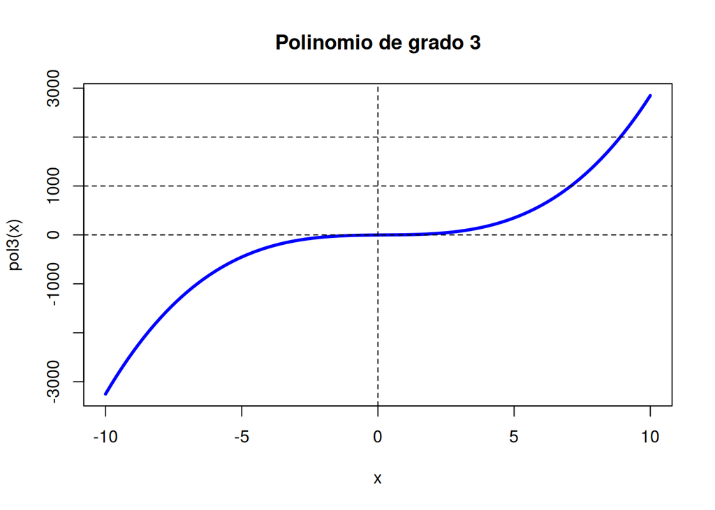

```r
curve(pol3, from = -10, to = 10, main = "Polinomio de grado 3",
      lwd = 3, col = "blue")
# agregar componentes a la gráfica
abline(h = c(0,1000,2000), lty = 2) #linea punteada
abline(v = 0, lty = 2)
```

Hagamos una función discontinua o definida a trozos

```r
g <- function(x){
     ifelse(x < 1, x^2 - 1,
        ifelse((1 < x) & (x < 2), x^3-5,
          ifelse(x > 2, 5 - 2*x , NA)))
}
g(3)
```

```
[1] -1
```

```r
g(c(-3,1,2,4))
```

```
[1]  8 NA NA -3
```

Hagamos la gráfica

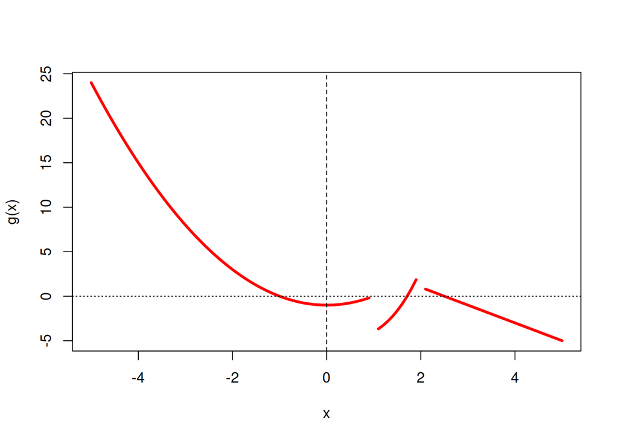

```r
curve(g, from = -5, to = 5, col = "red", lwd = 3)
abline(h = 0, lty = 3)
abline(v = 0, lty = 2)
```

Ahora consideremos la famosa “Campana” de Gauss (es la densidad de la distribución normal):

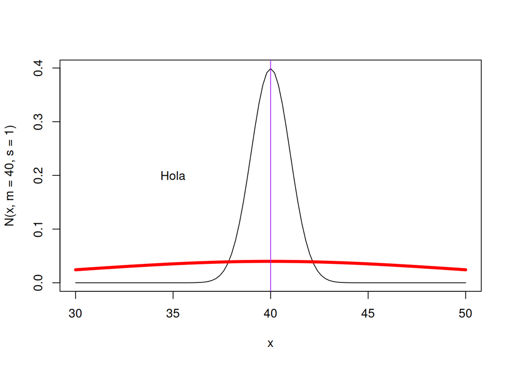

```r
N <- function(x, m = 0, s = 1){
  1/(s*sqrt(2*pi))*exp(-(x-m)^2/(2*s^2))
}
curve(N(x,m = 40, s= 1),from = 30, to = 50)
curve(N(x,m = 40, s= 10),from = 30, to = 50, add=T, col = "red", lwd = 4)
abline(v=40,col = "purple")
text(35,0.2,"Hola")
```

```r
N(1, m = 3)
```

```
[1] 0.05399097
```

```r
f1 <- function(x){
      s <- NULL # Valor inicial de s
      if(x ==1)s <- 10
      return(s)
}
f1(2)
```

```r
f1(1)
```

```
[1] 10
```

¿Cómo harían la composición entre pol3 y norm?

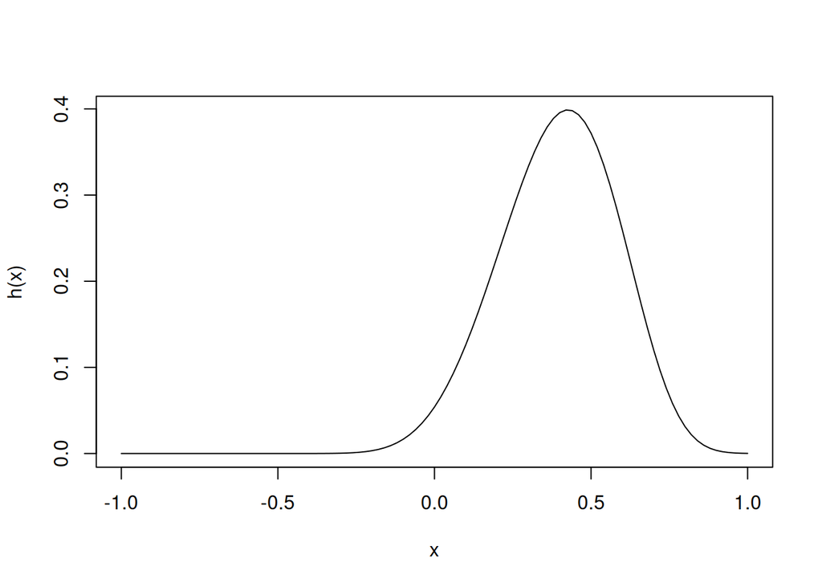

```r
h <- function(x){N(pol3(x))}
curve(h(x),from = -1,  to = 1)
```

y la composición entre norm y pol3:

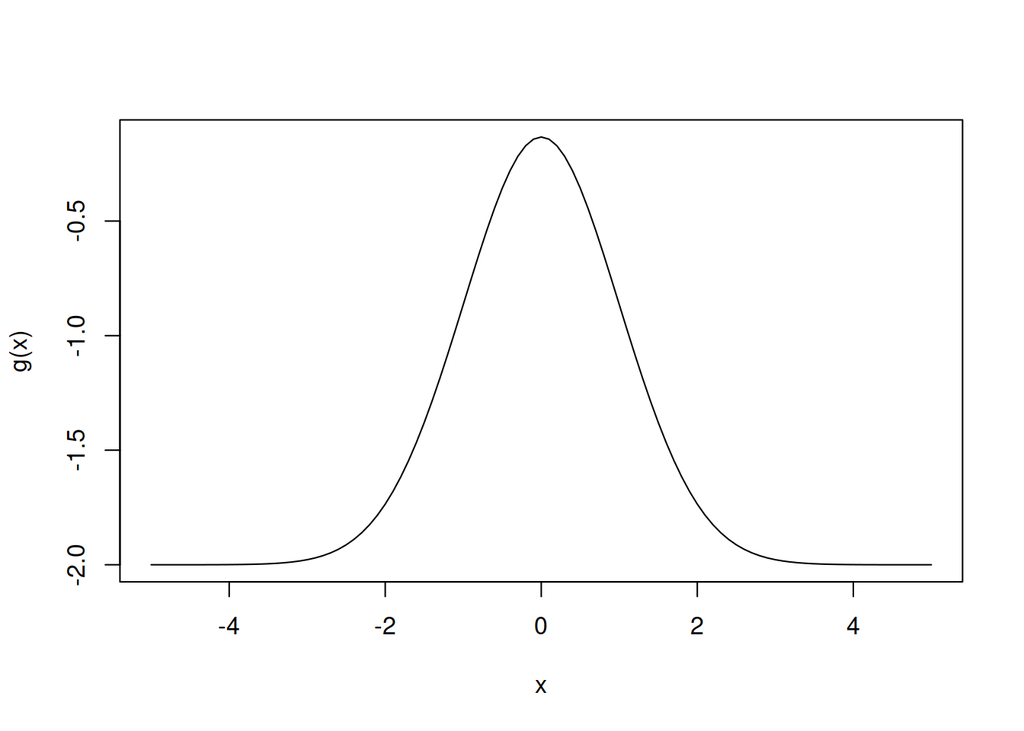

```r
g <- function(x){pol3(N(x))}
curve(g(x),from = -5,  to = 5)
```